# Log Transformations, Model Selection, and Bias Correction

Chapter 5: Lesson 2

## Learning Outcomes

**Apply logarithmic transformations to time series**

- Explain when to use a log-transformation
- Explain how a logarithm turns a multiplicative model into an additive model
- Explain how a logarithm linearizes an exponential trend
- Fit a regression model with seasonal indicator variables to a log-transformed time series

**Apply model selection criteria**

- Explain why adding terms to a model always improves the in-sample fit
- State the general structure of an information criterion as a measure of fit plus a penalty for complexity
- Compare candidate models using AIC, AICc, and BIC
- Explain why information criteria should inform, not replace, judgment when choosing a model
- Identify when information criteria cannot be compared across models

**Fit regression models with autocorrelated errors**

- Use the correlogram and partial correlogram of the residuals to choose an $AR(p)$ model for the errors
- Fit a regression model with $AR(p)$ errors as a single model
- Compare OLS standard errors to those from a model with $AR(p)$ errors

**Forecast from a log-transformed model**

- Forecast using the inverse transformation of a log-transformed model
- Explain why back-transforming the forecasted mean of the logarithm gives a biased forecast
- Explain that fable applies a bias adjustment to the forecasted mean automatically
- State the log-normal and empirical bias correction factors

## Preparation

- Read Sections 5.7, 5.9-5.11

## Learning Journal Exchange (10 min)

- Review another student’s journal
- What would you add to your learning journal after reading another student’s?
- What would you recommend the other student add to their learning journal?
- Sign the Learning Journal review sheet for your peer

## Packages

```r
pacman::p_load(
  tidyverse,  # ggplot, mutate(), cleaning...
  tsibble,    # as_tsibble()
  fable,      # model(...), forecast(), tidy(), glance()...
  feasts,     # ACF(), PACF()
  ggtime,     # autoplot() for tsibbles
  rio,        # import()
  pander,     # pander() markdown tables
  patchwork   # + and / for ggplots
)
```

## Class Activity: Why Take the Logarithm? (10 min)

In this lesson, we will build one model from start to finish. Each section answers one question:

1. **Why take the logarithm?** The log turns a multiplicative series into an additive one that a linear model can fit.
2. **What shape is the trend?** We fit several candidate trends and compare them.
3. **Which candidate should we use?** Information criteria help us weigh fit against complexity.
4. **Are the errors autocorrelated?** If so, we add an $AR(p)$ model for the errors.
5. **How do we forecast on the original scale?** We undo the logarithm and account for the bias that introduces.

### The Air Passenger Data

The textbook uses this data set in Section 5.7. It gives the monthly totals of international airline passengers (in thousands) from January 1949 to December 1960. The data come with R as a `ts` object called `AirPassengers`, so we convert them to a tsibble.

```r
air_ts <- as_tsibble(AirPassengers) |>
  rename(date = index, passengers = value) |>
  mutate(
    t             = row_number(),                                # t = 1 is January 1949
    years_elapsed = t / 12,                                      # years since Dec 1948 (not the calendar year)
    month         = factor(month.abb[month(date)], levels = month.abb)  # January is the reference month
  )
```

Figure 1 shows the time series (left) and the natural logarithm of the time series (right).

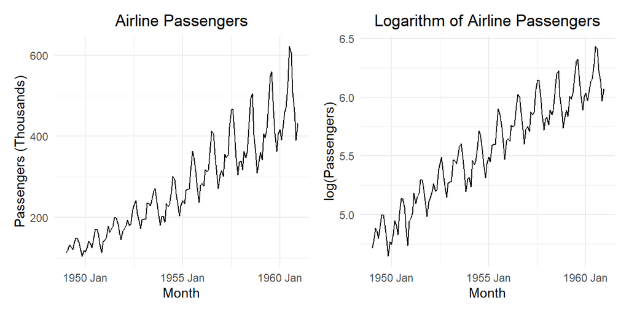

Figure 1: Monthly international airline passengers (left) and the natural logarithm of the series (right)

```r
air_plot_raw <- air_ts |>
  autoplot(.vars = passengers) +
  labs(
    x = "Month",
    y = "Passengers (Thousands)",
    title = "Airline Passengers"
  ) +
  theme_minimal() +
  theme(plot.title = element_text(hjust = 0.5))

air_plot_log <- air_ts |>
  autoplot(.vars = log(passengers)) +
  labs(
    x = "Month",
    y = "log(Passengers)",
    title = "Logarithm of Airline Passengers"
  ) +
  theme_minimal() +
  theme(plot.title = element_text(hjust = 0.5))

air_plot_raw | air_plot_log
```

Look at the left plot. The trend bends upward, and the seasonal swings get larger as the level of the series increases. In [Chapter 3 Lesson 5](https://byuistats.github.io/timeseries/chapter_3_lesson_5.html), we called this **multiplicative** seasonality. A multiplicative model has the form

$$x_t = m_t \cdot s_t \cdot z_t$$

The linear models from [Chapter 5 Lesson 1](https://byuistats.github.io/timeseries/chapter_5_lesson_1.html) are additive. They add the trend, seasonal, and random components together. We cannot fit a multiplicative model directly with `TSLM()`. However, taking the logarithm of both sides turns the products into sums:

$$\log(x_t) = \log(m_t) + \log(s_t) + \log(z_t)$$

The logarithm also straightens out an exponential trend. If $m_t = e^{\alpha_0 + \alpha_1 t}$, then $\log(m_t) = \alpha_0 + \alpha_1 t$, which is linear in the parameters.

Now look at the right plot. After taking the logarithm, the seasonal swings are roughly the same size throughout, and the trend looks close to a straight line. This is a series we can model with the tools from the last lesson. From here on, our response variable is $\log(x_t)$, not $x_t$.

**TipCheck Your Understanding**

- What two features of the left plot suggest that a log transformation is appropriate?
- How do those two features change in the right plot?
- Recall Model 10 from [Chapter 5 Lesson 1](https://byuistats.github.io/timeseries/chapter_5_lesson_1.html): $x_t = \alpha_0 ~ e^{ \alpha_1 t + \alpha_2 t^2 + z_t }$. Take the logarithm of both sides. Is the result a linear model?

## Class Activity: Candidate Models for the Trend (10 min)

The log-transformed series *looks* linear, but our eyes are not a precise tool. A slight curve in the trend is easy to miss. Rather than assume a shape, we will fit a few reasonable **candidate models** and let the data help us choose among them. We will consider a linear, quadratic, and cubic trend.

### The Model

All three candidates have the same structure as the models in [Chapter 5 Lesson 1](https://byuistats.github.io/timeseries/chapter_5_lesson_1.html), but the response is $\log(x_t)$:

$$\log(x_t) = m_t + s_t + z_t$$

The seasonal component $s_t$ uses indicator variables with January as the reference month, so each $\Delta\beta_i$ is the difference between that month and January:

$$s_t =
\begin{cases}
0, & t = 1, 13, 25, \ldots ~~~~ ~~(January) \\
\Delta\beta_2, & t = 2, 14, 26, \ldots ~~~~ ~~(February) \\
\Delta\beta_3, & t = 3, 15, 27, \ldots ~~~~ ~~(March) \\
~~~~⋮ & ~~~~~~~~~~~~⋮ \\
\Delta\beta_{12}, & t = 12, 24, 36, \ldots ~~~~ (December)
\end{cases}$$

The candidates differ only in the trend, $m_t$. Here $u_t$ is the time elapsed in years since December 1948, stored in `air_ts` as `years_elapsed`. We look more closely at this choice, and at what the coefficients mean, after we choose a model.

| Candidate | Trend, $m_t$ |
| --- | --- |
| Linear | $\alpha_0 + \alpha_1 u_t$ |
| Quadratic | $\alpha_0 + \alpha_1 u_t + \alpha_2 u_t^2$ |
| Cubic | $\alpha_0 + \alpha_1 u_t + \alpha_2 u_t^2 + \alpha_3 u_t^3$ |

### Fitting the Candidates

We fit all three candidates at once. Each model is fitted with ordinary least squares (OLS).

```r
air_models <- air_ts |>
  model(
    linear    = TSLM(log(passengers) ~ years_elapsed + month),
    quadratic = TSLM(log(passengers) ~ years_elapsed + I(years_elapsed^2) + month),
    cubic     = TSLM(log(passengers) ~ years_elapsed + I(years_elapsed^2) + I(years_elapsed^3) + month)
  )
```

The tabs below give the estimated trend parameters for each candidate. The 11 monthly terms are left out to save space. Delete the `filter()` line to see them.

**Linear**

```r
air_models |>
  select(linear) |>
  tidy() |>
  filter(!str_detect(term, "month")) |>
  mutate(sig = p.value < 0.05)
```

```
# A tibble: 2 × 7
  .model term          estimate std.error statistic   p.value sig
  <chr>  <chr>            <dbl>     <dbl>     <dbl>     <dbl> <lgl>
1 linear (Intercept)      4.73    0.0189      250.  1.97e-177 TRUE
2 linear years_elapsed    0.121   0.00143      84.4 4.56e-116 TRUE
```

**Quadratic**

```r
air_models |>
  select(quadratic) |>
  tidy() |>
  filter(!str_detect(term, "month")) |>
  mutate(sig = p.value < 0.05)
```

```
# A tibble: 3 × 7
  .model    term               estimate std.error statistic   p.value sig
  <chr>     <chr>                 <dbl>     <dbl>     <dbl>     <dbl> <lgl>
1 quadratic (Intercept)         4.65     0.0179      260.   1.45e-178 TRUE
2 quadratic years_elapsed       0.158    0.00467      33.9  2.27e- 66 TRUE
3 quadratic I(years_elapsed^2) -0.00309  0.000374     -8.26 1.41e- 13 TRUE
```

The quadratic term is statistically significant, and its estimate is negative. On the log scale, the trend bends slightly downward. In other words, the growth rate of passengers slows a little over time.

**Cubic**

```r
air_models |>
  select(cubic) |>
  tidy() |>
  filter(!str_detect(term, "month")) |>
  mutate(sig = p.value < 0.05)
```

```
# A tibble: 4 × 7
  .model term                 estimate std.error statistic   p.value sig
  <chr>  <chr>                   <dbl>     <dbl>     <dbl>     <dbl> <lgl>
1 cubic  (Intercept)         4.66       0.0207     225.    3.15e-169 TRUE
2 cubic  years_elapsed       0.150      0.0119      12.6   2.84e- 24 TRUE
3 cubic  I(years_elapsed^2) -0.00142    0.00228     -0.621 5.35e-  1 FALSE
4 cubic  I(years_elapsed^3) -0.0000924  0.000124    -0.744 4.58e-  1 FALSE
```

The cubic term is not statistically significant. Notice that the quadratic term is not significant in this model either, even though it was in the quadratic model. The terms $u_t$, $u_t^2$, and $u_t^3$ rise together and are highly correlated, so the model struggles to separate their individual effects. This is one reason we compare whole models in the next section rather than relying only on individual p-values.

**NoteReminder**

`TSLM()` estimates its parameters with ordinary least squares, exactly like `lm()`. As we saw in [Chapter 5 Lesson 1](https://byuistats.github.io/timeseries/chapter_5_lesson_1.html), if the errors are autocorrelated, these standard errors and p-values are too small. We will check the residuals and account for any autocorrelation after we choose a trend.

**TipCheck Your Understanding**

- Based on the plots and the p-values, which trend do you think is most appropriate? Why?

## Model Selection Information Criteria: Balancing Fit and Complexity (15 min)

We now have three candidate models. How do we choose?

### Why We Need a Penalty

Adding terms to a regression model never makes the in-sample fit worse. The $R^2$ value can only go up, and the residual sum of squares can only go down. If we chose models by $R^2$ alone, we would always choose the most complicated model. But a model that follows the training data too closely (**overfitting**) often forecasts poorly, because some of what it learned was noise.

You may remember **adjusted $R^2$** from a regression course, which does include a penalty for extra terms. Its penalty is weak, though. Adjusted $R^2$ goes up whenever a new term has a t-statistic larger than 1 in absolute value, so it still tends to keep terms that add little. It is also specific to regression. It does not exist for the models with autocorrelated errors that we fit later in this lesson. Information criteria solve both problems.

The idea behind information criteria is **parsimony**: when two models explain the data about equally well, we prefer the simpler one. Every information criterion has the same structure:

$$\text{IC} = \underbrace{-2 \log(\mathcal{L})}_{\text{lack of fit}} + \underbrace{\text{penalty}(k)}_{\text{complexity}}$$

where $\mathcal{L}$ is the likelihood of the data under the model (how probable the observed data are, given the fitted model) and $k$ is the number of estimated parameters. Better fit makes the first term smaller. More parameters make the second term larger. **Smaller values are better.**

### Three Common Criteria

**AIC (Akaike Information Criterion)**

$$AIC = -2 \log(\mathcal{L}) + 2k$$

The AIC estimates how much information is lost when we use the model to represent the process that generated the data. It is designed to choose the model that will predict new data best, so it is well suited to forecasting.

**AICc (Corrected AIC)**

$$AICc = AIC + \frac{2k(k+1)}{n - k - 1}$$

When the sample size $n$ is small relative to $k$, the AIC tends to choose models that are too complex. The AICc adds an extra penalty to correct for this. As $n$ grows, the correction shrinks and the AICc approaches the AIC. Because time series are often short, the AICc is a good default.

**BIC (Bayesian Information Criterion)**

$$BIC = -2 \log(\mathcal{L}) + k \ln(n)$$

The BIC penalizes each parameter by $\ln(n)$ instead of 2. Since $\ln(n) > 2$ whenever $n > 7$, the BIC is stricter than the AIC and tends to choose simpler models. It is often preferred when the goal is to understand or explain a process rather than to forecast it.

### Comparing the Candidates

Table 1 gives $R^2$, adjusted $R^2$, and the three information criteria for each candidate. The lowest value in each criterion column is in bold.

```r
air_ic <- air_models |>
  glance() |>
  select(.model, r_squared, adj_r_squared, AIC, AICc, BIC)

air_ic
```

Table 1: Fit statistics for the candidate models fitted to the logarithm of the airline passenger series

| Model | R-squared | Adj. R-squared | AIC | AICc | BIC |
| --- | --- | --- | --- | --- | --- |
| linear | 0.9835 | 0.9820 | -799.2 | -796 | -757.7 |
| quadratic | 0.9892 | 0.9881 | **-858.1** | **-854.3** | **-813.5** |
| cubic | 0.9892 | 0.9880 | -856.7 | -852.4 | -809.2 |

Notice the following:

- $R^2$ increases with every term we add, as expected. It cannot tell us when to stop. Adjusted $R^2$ barely separates the quadratic and cubic models.
- The linear model is far behind the other two on every criterion. The quadratic term is earning its keep.
- The quadratic model has the lowest AIC, AICc, and BIC. Adding a cubic term improves the fit slightly, but not enough to justify the extra parameter.

### Reading Information Criteria Carefully

**ImportantInformation criteria inform a decision. They do not make it.**

It is tempting to treat information criteria as a score to optimize: fit everything, choose the smallest number, and stop. Resist this. The criteria are one piece of evidence in a broader discussion of what the model is for and what trade-offs you are willing to make.

- **Only differences matter.** The value of the AIC on its own means nothing. What matters is how far apart two models are. As a rough guide, models within about 2 units of each other are about equally supported by the data. A difference of 10 or more is strong evidence for the lower model.
- **A small difference is a tie.** When two models are close, the criteria have not chosen for you. Use other considerations, such as simplicity, interpretability, and whether the model makes sense for the process.
- **The criteria can disagree.** The AICc leans toward models that forecast well, and the BIC leans toward simpler models. A disagreement tells you something about the trade-off. It is not a problem to be resolved by picking a favorite.
- **They say nothing about assumptions.** A model can have the lowest AICc and still have autocorrelated residuals. You still need to check the residuals.
- **Think about the purpose.** The quadratic model has a negative $u_t^2$ term. If we extended it far enough into the future, it would predict that air travel eventually *declines*. For a forecast a few years ahead, this is not a concern. For a forecast decades ahead, the linear model might be the more sensible choice, even though it fits these data worse.
- **Only compare models fitted to the same response.** See the example below.

The last point deserves an example. Below, we compare a quadratic model fitted to the original series with the same model fitted to the logarithm.

```r
# Shift that puts the log model's AICc in the units of x_t (explained below)
log_shift <- 2 * sum(log(air_ts$passengers))

air_scale_ic <- air_ts |>
  model(
    original = TSLM(passengers ~ years_elapsed + I(years_elapsed^2) + month),
    log      = TSLM(log(passengers) ~ years_elapsed + I(years_elapsed^2) + month)
  ) |>
  glance()

air_scale_ic |>
  transmute(
    Model = c("Quadratic, original scale", "Quadratic, log scale"),
    Response = c("x_t", "log(x_t)"),
    "Units of response" = c("thousands of passengers", "log(thousands of passengers)"),
    AICc = round(AICc, 1),
    "AICc in units of x_t" = round(AICc + c(0, log_shift), 1)
  ) |>
  pander(split.table = Inf)
```

| Model | Response | Units of response | AICc | AICc in units of x_t |
| --- | --- | --- | --- | --- |
| Quadratic, original scale | x_t | thousands of passengers | 931.2 | 931.2 |
| Quadratic, log scale | log(x_t) | log(thousands of passengers) | -854.3 | 741.8 |

Look at the AICc column first. The two values are about 1,800 units apart. Taken at face value, this would be overwhelming evidence for the log model, but the comparison is not fair.

The likelihood measures how probable the observed data are, so it is measured in the units of the response. A density for $\log(x_t)$ and a density for $x_t$ are on different scales. Converting from one to the other multiplies the density of each observation by $1/x_t$. Over the whole series, that shifts $-2\log(\mathcal{L})$, and therefore the AICc, by

$$2 \sum_{t=1}^{n} \log(x_t) = 1596.1$$

for these data. Adding this amount to the log model’s AICc puts both models in the units of $x_t$, as shown in the last column. On a common scale, the log model is still better, but by about 189 units, not 1,800. Most of the original gap came from the change of units, not from the models.

In practice, we rarely make this adjustment. We choose a transformation based on the time plot and the residuals, and then use information criteria to compare models that share that transformation.

### Our Decision

We will use the quadratic trend. It has the lowest value on all three criteria, the quadratic term is meaningful, and the cubic term adds nothing. Its slowing growth rate is reasonable for the short-term forecasts we will make.

**TipCheck Your Understanding**

- Why can’t we use $R^2$ to choose between these models?
- Explain the trade-off that every information criterion is trying to balance.
- Suppose the cubic model had an AICc 1 unit *lower* than the quadratic model. Would you choose the cubic model? What else would you consider?
- Why is it misleading to compare the AICc of a model for $x_t$ directly with the AICc of a model for $\log(x_t)$?

### Interpreting the Coefficients

Now that we have chosen the quadratic model, what do its coefficients tell us about airline travel?

#### Measuring Time

The answer depends on how we measured time. A trend needs a variable that measures time. When we created `air_ts`, we made two:

- `t` counts months. $t = 1$ is January 1949, $t = 2$ is February 1949, and so on.
- `years_elapsed` $= u_t = t/12$ counts the same months in units of years.

`years_elapsed` is **not** the calendar year. It is the time elapsed since December 1948, the month before the data begin. Each month adds $1/12$:

| Month | `t` | `years_elapsed` |
| --- | --- | --- |
| Jan 1949 | 1 | 0.083 |
| Feb 1949 | 2 | 0.167 |
| Dec 1949 | 12 | 1.000 |
| Jan 1950 | 13 | 1.083 |
| Dec 1960 | 144 | 12.000 |

So $u_t = 0$ is December 1948, and a one-unit change in $u_t$ is one year.

**NoteUnder the Hood: Why `years_elapsed` and Not `trend()` or the Calendar Year?**

**fable’s `trend()`.** fable has shortcuts for these variables. `trend()` creates `t`, counting observations 1, 2, 3, … in the units of the data, which here are months. `season()` creates the month indicators with January as the reference. The code below fits the linear candidate both ways.

```r
air_units <- air_ts |>
  model(
    years_elapsed = TSLM(log(passengers) ~ years_elapsed + month),
    trend         = TSLM(log(passengers) ~ trend() + season())
  )
```

```r
units_coef <- tidy(air_units) |>
  filter(term %in% c("(Intercept)", "years_elapsed", "trend()", "monthFeb", "season()year2"))

units_coef |>
  select(Model = .model, Term = term, Estimate = estimate) |>
  round_df(4) |>
  display_table()
slope_years  <- units_coef |> filter(term == "years_elapsed") |> pull(estimate)
slope_months <- units_coef |> filter(term == "trend()") |> pull(estimate)
fitted_diff  <- max(abs(
  fitted(air_units |> select(years_elapsed))$.fitted -
    fitted(air_units |> select(trend))$.fitted
))
```

Table 2: Three coefficients from the linear candidate, fitted with `years_elapsed` and `month` or with `trend()` and `season()`

| Model | Term | Estimate |
| --- | --- | --- |
| years_elapsed | (Intercept) | 4.7268 |
| years_elapsed | years_elapsed | 0.1208 |
| years_elapsed | monthFeb | -0.0221 |
| trend | (Intercept) | 4.7268 |
| trend | trend() | 0.0101 |
| trend | season()year2 | -0.0221 |

These are the same model. Their fitted values differ by less than $10^{-12}$, which is rounding error, so they also give the same forecasts. The intercepts match. The February coefficients match too; `season()year2` is fable’s name for `monthFeb`. Only the slopes differ, by a factor of 12:

- `trend()` counts months, so its slope, 0.0101, is the change in $\log(x_t)$ per **month**.
- `years_elapsed` counts years, so its slope, 0.1208 $= 12 \times$ 0.0101, is the change per **year**.

We use `years_elapsed` in this lesson for two reasons. Its coefficients describe change per year, which is easier to talk about. It also keeps powers of time small: by the end of the series, $u_t^3 = 1{,}728$, while $t^3$ is about 3,000,000. Numbers that large can cause numerical problems, including in the regression with $AR(1)$ errors we fit later in this lesson. The cost is that when we forecast, we must create the future values of `years_elapsed` ourselves. `trend()` would do that for us.

**The calendar year.** For the global temperatures in [Chapter 5 Lesson 1](https://byuistats.github.io/timeseries/chapter_5_lesson_1.html), we measured time with the calendar year (`stats_time` = 1970.00, 1970.08, …). That works for a straight line, but it breaks down here.

```r
air_calendar <- air_ts |>
  mutate(calendar_year = year(date) + (month(date) - 1) / 12) |>
  model(
    linear    = TSLM(log(passengers) ~ calendar_year + month),
    quadratic = TSLM(log(passengers) ~ calendar_year + I(calendar_year^2) + month),
    cubic     = TSLM(log(passengers) ~ calendar_year + I(calendar_year^2) + I(calendar_year^3) + month)
  )

tidy(air_calendar) |>
  filter(!str_detect(term, "^month")) |>
  select(Model = .model, Term = term, Estimate = estimate) |>
  mutate(Estimate = map_chr(Estimate, \(x) format(signif(x, 3), scientific = FALSE, big.mark = ","))) |>
  display_table()
```

| Model | Term | Estimate |
| --- | --- | --- |
| linear | (Intercept) | -231 |
| linear | calendar_year | 0.121 |
| quadratic | (Intercept) | -12,100 |
| quadratic | calendar_year | 12.2 |
| quadratic | I(calendar_year^2) | -0.00309 |
| cubic | (Intercept) | -12,100 |
| cubic | calendar_year | 12.2 |
| cubic | I(calendar_year^2) | -0.00309 |
| cubic | I(calendar_year^3) | NA |

- **The intercept is the value in year 0 AD.** In the linear model, $\alpha_0$ is the predicted log number of passengers two thousand years before airplanes.
- **With a quadratic, $\alpha_1$ becomes the slope in year 0 AD.** It is about 12 per year, a growth rate that never happened anywhere near the data.
- **The powers are nearly identical.** Over 1949–1960, `calendar_year` and its square have a correlation of 0.9999997. `TSLM()` cannot separate the cubic term from the others, so it silently drops that term and reports `NA`.

Measuring time from the start of the series avoids all three problems.

#### Reading the Estimates

Table 3 gives the trend coefficients and one seasonal coefficient from the quadratic model. These are the OLS estimates. When we add $AR(1)$ errors in the next activity, the estimates barely change, so the interpretation below still holds.

```r
quad_coef <- air_models |>
  select(quadratic) |>
  tidy() |>
  filter(term %in% c("(Intercept)", "years_elapsed", "I(years_elapsed^2)", "monthJul"))

quad_coef |>
  select(Term = term, Estimate = estimate) |>
  round_df(4) |>
  display_table()
get_est <- function(name) quad_coef |> filter(term == name) |> pull(estimate)
a0  <- get_est("(Intercept)")
a1  <- get_est("years_elapsed")
a2  <- get_est("I(years_elapsed^2)")
jul <- get_est("monthJul")

slope_start <- a1                 # slope of the trend at u_t = 0
slope_end   <- a1 + 2 * a2 * 12   # slope of the trend at u_t = 12 (Dec 1960)
pct <- function(x) round(100 * (exp(x) - 1), 1)
```

Table 3: Selected coefficients from the quadratic model for the logarithm of airline passengers

| Term | Estimate |
| --- | --- |
| (Intercept) | 4.6514 |
| years_elapsed | 0.1582 |
| I(years_elapsed^2) | -0.0031 |
| monthJul | 0.3000 |

Because the response is $\log(x_t)$, a change of $c$ on the log scale multiplies $x_t$ by $e^c$. That turns each coefficient into a statement about percent change.

- **The intercept.** $\hat\alpha_0 =$ 4.651 is the fitted value of $\log(x_t)$ at $u_t = 0$ for the reference month, January. On the original scale, $e^{\hat\alpha_0} \approx$ 105 thousand passengers. This is where the trend starts, just before the data begin.
- **The trend.** With a quadratic, the slope of the trend changes over time. It is $\hat\alpha_1 + 2\hat\alpha_2 u_t$, so $\hat\alpha_1$ alone is only the slope at $u_t = 0$. At the start of the series, the trend grows by about 17.1% per year. By December 1960 ($u_t = 12$), the growth rate has slowed to about 8.8% per year. This is the slowing growth that the negative quadratic term describes.
- **The seasonal terms.** $\Delta\hat\beta_7 =$ 0.3 for July. Holding the trend fixed, July has about 35% more passengers than January, every year. On the original scale, the seasonal terms multiply the trend instead of adding to it, so the seasonal swings grow as the series grows. This is the pattern in Figure 1 that led us to take the logarithm.

**TipCheck Your Understanding**

- The quadratic term is negative. What does that mean for the growth of airline passengers?
- Why can’t we read $\hat\alpha_1$ by itself as “the growth rate of the trend”?
- Use Table 3 to find the percent difference between July and January. Why do we need $e^{\Delta\hat\beta_7} - 1$ instead of $\Delta\hat\beta_7$ itself?

## Class Activity: Modeling the Autocorrelated Errors (15 min)

We have chosen a trend and a seasonal component. Now we check the errors. Recall from [Chapter 5 Lesson 1](https://byuistats.github.io/timeseries/chapter_5_lesson_1.html) that if the errors are autocorrelated, OLS underestimates the standard errors of the parameter estimates. Our confidence intervals will be too narrow, and some terms may appear significant when they are not.

### Checking the Residuals

Figure 2 gives the correlogram and partial correlogram of the residuals from the quadratic model.

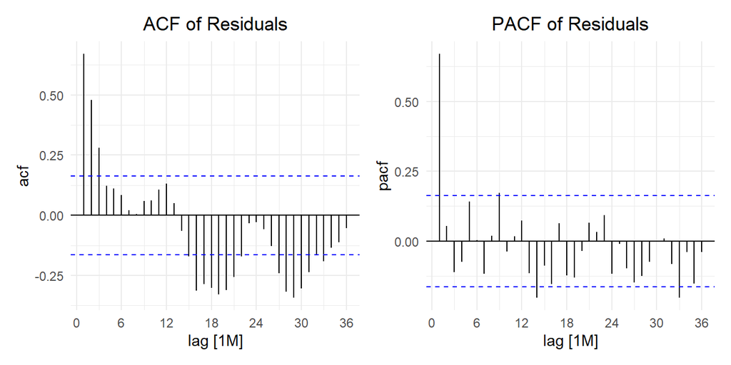

Figure 2: Correlogram (left) and partial correlogram (right) of the residuals from the OLS model with a quadratic trend

```r
air_quad_resid <- air_models |>
  select(quadratic) |>
  residuals()

air_acf_plot <- air_quad_resid |>
  ACF(.resid, lag_max = 36) |>
  autoplot() +
  labs(title = "ACF of Residuals") +
  theme_minimal() +
  theme(plot.title = element_text(hjust = 0.5))

air_pacf_plot <- air_quad_resid |>
  PACF(.resid, lag_max = 36) |>
  autoplot() +
  labs(title = "PACF of Residuals") +
  theme_minimal() +
  theme(plot.title = element_text(hjust = 0.5))

air_acf_plot | air_pacf_plot
```

The correlogram shows strong positive autocorrelation at short lags that dies out after a few months. The partial correlogram has a single large spike at lag 1 and is small after that. This is the pattern of an $AR(1)$ process, so we will model the errors as

$$z_t = \phi_1 z_{t-1} + w_t$$

where $\{w_t\}$ is white noise.

### Regression with AR(1) Errors

We do not fit the regression and then fit a separate AR model to its residuals. Instead, we fit **one model** that estimates the trend, the seasonal terms, and the AR coefficient together:

$$\begin{align*}
\log(x_t) &= \alpha_0 + \alpha_1 u_t + \alpha_2 u_t^2 + s_t + z_t \\
z_t &= \phi_1 z_{t-1} + w_t
\end{align*}$$

As in [Chapter 5 Lesson 1](https://byuistats.github.io/timeseries/chapter_5_lesson_1.html), we do this with the `ARIMA()` function. The `pdq(1, 0, 0)` term asks for $AR(1)$ errors, and `PDQ(0, 0, 0)` turns off the seasonal ARIMA terms, since the indicator variables already handle seasonality. You will learn the rest of what `ARIMA()` can do in Chapter 7.

```r
air_ar <- air_ts |>
  model(
    quad_ar1 = ARIMA(log(passengers) ~ years_elapsed + I(years_elapsed^2) + month + pdq(1, 0, 0) + PDQ(0, 0, 0))
  )

air_ar |>
  tidy() |>
  filter(!str_detect(term, "month"))
```

```
# A tibble: 4 × 6
  .model   term               estimate std.error statistic   p.value
  <chr>    <chr>                 <dbl>     <dbl>     <dbl>     <dbl>
1 quad_ar1 ar1                 0.674    0.0613       11.0  7.85e- 21
2 quad_ar1 years_elapsed       0.156    0.00942      16.6  2.94e- 35
3 quad_ar1 I(years_elapsed^2) -0.00298  0.000756     -3.94 1.25e-  4
4 quad_ar1 intercept           4.66     0.0260      179.   4.58e-171
```

**NoteUnder the Hood: Why Not `trend()` Here?**

`TSLM()` accepts `I(trend()^2)`, but `ARIMA()` handles the large values poorly. By the end of the series, `trend()` reaches 144 and its square reaches 20,736, while `years_elapsed` only reaches 12. Below, we fit the same model using `trend()`. The standard error of the squared term comes back `NaN`. The model above, fitted with `years_elapsed`, has no such problem.

```r
air_ts |>
  model(ARIMA(log(passengers) ~ trend() + I(trend()^2) + season() + pdq(1, 0, 0) + PDQ(0, 0, 0))) |>
  tidy() |>
  filter(term %in% c("trend()", "I(trend()^2)")) |>
  select(Term = term, Estimate = estimate, SE = std.error) |>
  mutate(across(c(Estimate, SE), \(col) map_chr(col, \(x) format(signif(x, 3), scientific = FALSE)))) |>
  display_table()
```

| Term | Estimate | SE |
| --- | --- | --- |
| trend() | 0.013 | 0.000526 |
| I(trend()^2) | -0.0000207 | NaN |

Table 4 compares the trend estimates and standard errors from the OLS model with those from the model with $AR(1)$ errors.

```r
bind_rows(
  air_models |> select(quadratic) |> tidy(),
  air_ar |> tidy()
) |>
  filter(term %in% c("years_elapsed", "I(years_elapsed^2)")) |>
  mutate(
    term = if_else(term == "years_elapsed", "alpha_1 (years_elapsed)", "alpha_2 (years_elapsed^2)"),
    .model = if_else(.model == "quadratic", "OLS", "AR(1) errors")
  ) |>
  select(.model, term, estimate, std.error) |>
  pivot_wider(names_from = .model, values_from = c(estimate, std.error)) |>
  select(
    Parameter = term,
    "OLS Estimate" = estimate_OLS,
    "OLS SE" = std.error_OLS,
    "AR(1) Estimate" = `estimate_AR(1) errors`,
    "AR(1) SE" = `std.error_AR(1) errors`
  ) |>
  round_df(4) |>
  display_table()
```

Table 4: Trend estimates and standard errors from OLS and from the regression with AR(1) errors

| Parameter | OLS Estimate | OLS SE | AR(1) Estimate | AR(1) SE |
| --- | --- | --- | --- | --- |
| alpha_1 (years_elapsed) | 0.1582 | 0.0047 | 0.1563 | 0.0094 |
| alpha_2 (years_elapsed^2) | -0.0031 | 0.0004 | -0.0030 | 0.0008 |

The estimates barely change, but the standard errors roughly double. This is the problem from Chapter 5 Lesson 1 in a real data set: OLS made us more confident in the trend than the data justify. The quadratic term is still clearly significant, so our choice of trend holds up.

**Warning**

Do not compare the AICc of this model with the AICc values in Table 1. `TSLM()` and `ARIMA()` compute the likelihood differently, so their information criteria are on different scales. Compare information criteria only among models fitted with the same function and the same response.

Finally, we check that the $AR(1)$ term has dealt with the autocorrelation. This model has two kinds of residuals, one for each line of the model.

The **regression residuals** estimate $z_t$. They are what is left after removing the trend and seasonal terms:

$$\hat z_t = \log(x_t) - \left( \hat\alpha_0 + \hat\alpha_1 u_t + \hat\alpha_2 u_t^2 + \hat s_t \right)$$

These are like the residuals in Figure 2. We expect them to be autocorrelated, because that autocorrelation is what the $AR(1)$ term models.

The **innovation residuals** estimate $w_t$. They are what is left after also removing the part of $z_t$ that can be predicted from the previous month:

$$\hat w_t = \hat z_t - \hat\phi_1 \hat z_{t-1}$$

The innovation residuals are the part of the series that the full model, including the AR term, cannot explain. If the model is adequate, they should look like white noise. Both kinds of residuals are on the log scale. In fable, `augment()` returns the innovation residuals in the `.innov` column.

**Warning**

For a model with a transformed response, the `.resid` column from `augment()` is neither of these. It holds the **response residuals**, $x_t - \hat x_t$, on the original scale (passengers, not log passengers). Use `.innov` to check the model.

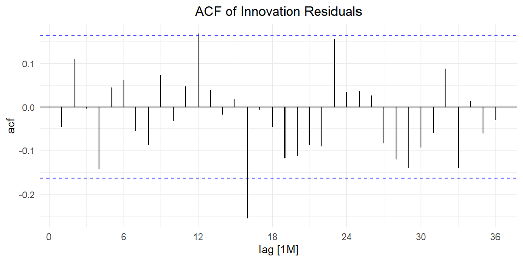

Figure 3: Correlogram of the innovation residuals from the regression with AR(1) errors

```r
air_ar |>
  augment() |>
  ACF(.innov, lag_max = 36) |>
  autoplot() +
  labs(title = "ACF of Innovation Residuals") +
  theme_minimal() +
  theme(plot.title = element_text(hjust = 0.5))
```

The strong short-lag autocorrelation is gone. Lag 16 crosses the significance bounds and lag 12 touches them. With 36 lags, we expect one or two to cross by chance (about 5% of them), and there is no remaining pattern at the short lags the $AR(1)$ term was meant to handle. The $AR(1)$ error model is adequate for our purposes. The small spike at lag 12 is a hint that the seasonal pattern may not be perfectly constant over the 12 years, which is something we could revisit with more advanced models.

**TipCheck Your Understanding**

- What feature of the partial correlogram led us to choose an $AR(1)$ model for the errors?
- Why did the standard errors increase when we added $AR(1)$ errors, while the estimates stayed about the same?
- What is the difference between the residuals in Figure 2 and the innovation residuals in Figure 3?

## Class Activity: Forecasting and Bias Correction (10 min)

### Forecasting on the Original Scale

Our model describes $\log(x_t)$, but we want forecasts of the number of passengers. Because we wrote `log(passengers)` in the model formula, fable undoes the transformation for us. The forecasts it returns are already on the original scale.

To forecast, we need future values of every predictor in the model. Because we measured time with `years_elapsed` instead of fable’s `trend()`, we have to build these ourselves; `trend()` would have extended itself automatically. We create three years of future months, continue the time index $t$ from where the data end, and assign each future month its month label.

```r
n_months_forecast <- 36

air_future <- new_data(air_ts, n = n_months_forecast) |>
  mutate(
    t             = nrow(air_ts) + row_number(),
    years_elapsed = t / 12,
    month         = factor(month.abb[month(date)], levels = month.abb)
  )

air_fc <- air_ar |>
  forecast(new_data = air_future)
```

Figure 4 shows the fitted values (blue) and the forecasts with a 95% prediction interval.

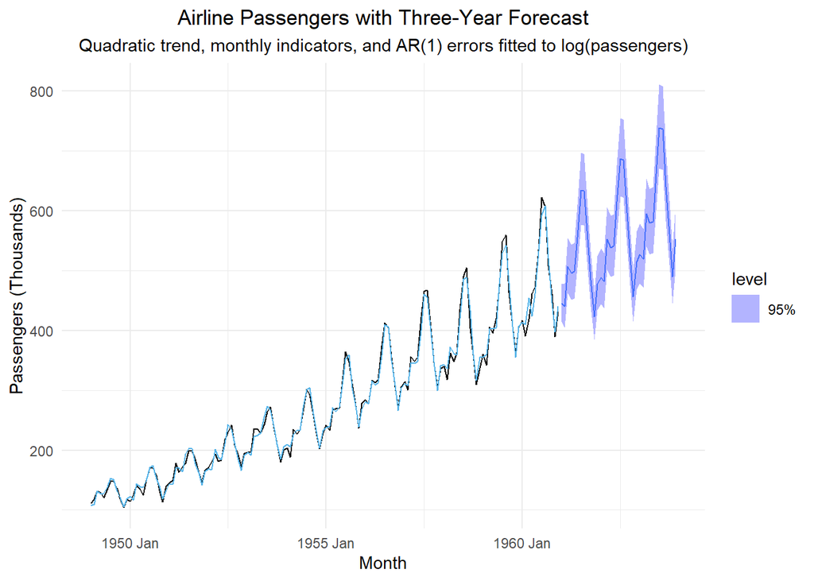

Figure 4: Airline passengers (black), fitted values (blue), and three-year forecast with 95% prediction interval

```r
air_fc |>
  autoplot(air_ts, level = 95) +
  geom_line(
    data = augment(air_ar),
    aes(x = date, y = .fitted),
    color = "#56B4E9"
  ) +
  labs(
    x = "Month",
    y = "Passengers (Thousands)",
    title = "Airline Passengers with Three-Year Forecast",
    subtitle = "Quadratic trend, monthly indicators, and AR(1) errors fitted to log(passengers)"
  ) +
  theme_minimal() +
  theme(
    plot.title = element_text(hjust = 0.5),
    plot.subtitle = element_text(hjust = 0.5)
  )
```

Notice that the prediction interval is not symmetric. It stretches farther above the forecast than below it. A symmetric interval on the log scale becomes lopsided when we exponentiate it.

### Why Back-Transforming Introduces Bias

The model gives us a forecast distribution for $\log(x_t)$ with a mean, $\mu$, and a variance, $\sigma^2$. The simplest way to get back to the original scale is to compute $e^{\mu}$. But averaging and exponentiating do not commute: the exponential of the mean is *not* the mean of the exponential.

On the log scale, the forecast distribution is symmetric, so $\mu$ is both its mean and its median. Exponentiating keeps values in the same order, so $e^{\mu}$ is still the **median** on the original scale. But the exponential function stretches large values more than small ones, which pulls the **mean** above the median. Using $e^{\mu}$ as a forecast of the mean would be biased low. If the log values are normally distributed, the mean on the original scale is

$$e^{\mu + \frac{1}{2}\sigma^2} = e^{\mu} \cdot e^{\frac{1}{2}\sigma^2}$$

The factor $e^{\frac{1}{2}\sigma^2}$ is the **bias correction**.

### fable Corrects the Bias for You

When the model formula contains a transformation, the `.mean` column that fable returns is already bias-adjusted. The forecast distribution column, `passengers`, holds the full distribution, so we can also ask it for the median, $e^{\mu}$. Table 5 compares the two.

```r
air_bias <- air_fc |>
  as_tibble() |>
  mutate(
    median = median(passengers),   # e^mu: back-transformed, no correction
    ratio  = .mean / median        # the bias correction fable applied
  ) |>
  select(date, median, .mean, ratio)

air_bias
```

Table 5: Back-transformed forecast medians and bias-adjusted means from fable

| Month | Median (no correction) | Mean (fable .mean) | Ratio |
| --- | --- | --- | --- |
| 1961 Jan | 445.0474 | 445.331 | 1.0006 |
| 1961 Feb | 440.1291 | 440.5371 | 1.0009 |
| 1961 Mar | 506.202 | 506.7381 | 1.0011 |
| 1961 Apr | 494.9101 | 495.4639 | 1.0011 |
| ⋮ | ⋮ | ⋮ | ⋮ |
| 1963 Nov | 489.0402 | 489.6119 | 1.0012 |
| 1963 Dec | 551.7405 | 552.3855 | 1.0012 |

The `.mean` column is slightly larger than the median, and the ratio between them is the bias correction. The correction grows slightly with the forecast horizon, because the forecast variance $\sigma^2$ grows as we forecast farther ahead. For these data, the correction is small (well under 1%), because the model fits the log series closely. For a noisier series, it can be much larger.

**ImportantKey Points**

- fable’s forecast `.mean` is **already bias-corrected** when the model formula includes a transformation like `log()`.
- **Do not multiply `.mean` by a correction factor.** That corrects the bias twice.
- The fitted values from `augment()` are back-transformed *without* a correction. They are medians, not means.

**NoteUnder the Hood: The Textbook’s Correction Factors**

Section 5.10 of the textbook gives two correction factors for back-transformed values. Both multiply the uncorrected (median) value, $e^{\mu}$. fable uses a version of the first one.

**Log-normal correction.** If the residuals on the log scale are approximately normal with variance $\sigma^2$:

$$\hat x_t' = e^{\frac{1}{2} \sigma^2} \cdot e^{\widehat{\log x_t}}$$

**Empirical correction.** If the residuals are not approximately normal (for example, if they are noticeably skewed), we replace the normal-theory factor with the average of the exponentiated residuals:

$$\hat x_t' = e^{\widehat{\log x_t}} \cdot \frac{1}{n} \sum_{t=1}^{n} e^{w_t}$$

where $\{w_t\}$ is the residual series on the log scale.

To decide which applies, we look at the shape of the residuals. Figure 5 gives a histogram of the innovation residuals with a normal curve for comparison.

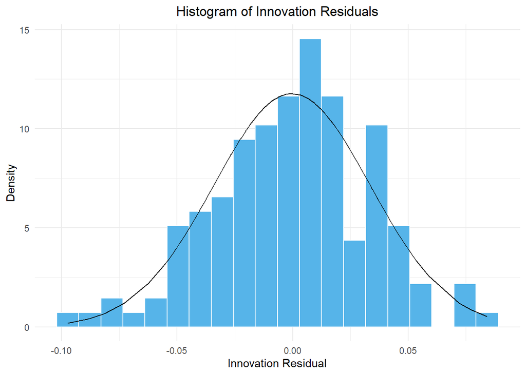

Figure 5: Histogram of the innovation residuals from the regression with AR(1) errors

```r
air_innov <- air_ar |>
  augment() |>
  pull(.innov)

tibble(x = air_innov) |>
  mutate(density = dnorm(x, mean(air_innov), sd(air_innov))) |>
  ggplot(aes(x = x)) +
  geom_histogram(aes(y = after_stat(density)),
                 color = "white", fill = "#56B4E9", bins = 20) +
  geom_line(aes(y = density)) +
  labs(
    x = "Innovation Residual",
    y = "Density",
    title = "Histogram of Innovation Residuals"
  ) +
  theme_minimal() +
  theme(plot.title = element_text(hjust = 0.5))
```

We can also measure the asymmetry with the skewness, the average cubed standardized residual:

$$\text{skewness} = \frac{1}{n} \sum_{t=1}^{n} \left( \frac{w_t - \bar w}{s_w} \right)^3$$

```r
air_skew <- mean(((air_innov - mean(air_innov)) / sd(air_innov))^3)
```

The skewness of the residuals is -0.219. A skewness between -0.5 and 0.5 suggests the distribution is roughly symmetric. Skewness between 0.5 and 1 in absolute value is moderate, and above 1 is high.

```r
air_sigma2 <- glance(air_ar)$sigma2

tibble(
  lognormal_cf = exp(air_sigma2 / 2),   # log-normal correction factor
  empirical_cf = mean(exp(air_innov)),  # empirical correction factor
  fable_1_step = air_bias$ratio[1]      # ratio fable applied one month ahead
) |>
  round_df(5) |>
  display_table()
```

| lognormal_cf | empirical_cf | fable_1_step |
| --- | --- | --- |
| 1.00064 | 1.00024 | 1.00064 |

The log-normal factor and the ratio fable applied one month ahead are nearly identical. The textbook factors use the variance of the residuals, so they are appropriate for fitted values and one-step forecasts. fable uses the forecast variance at each horizon, which is why its correction grows over time.

If the residuals were clearly skewed and you wanted the empirical correction instead, you would apply it to the **median**, not to `.mean`:

```r
air_fc |>
  mutate(empirical_mean = median(passengers) * mean(exp(air_innov)))
```

**TipCheck Your Understanding**

- Explain in your own words why $e^{\mu}$ is a biased forecast of the mean on the original scale.
- Your teammate computes `.mean * exp(sigma2 / 2)` from a fable forecast. What is wrong with this?
- Why does the bias correction grow as the forecast horizon increases?

## Small-Group Activity: Industrial Electricity Consumption in Texas (20 min)

These data give the amount of electricity (in megawatt-hours) used each month for industrial purposes in Texas from 2010 through 2023.

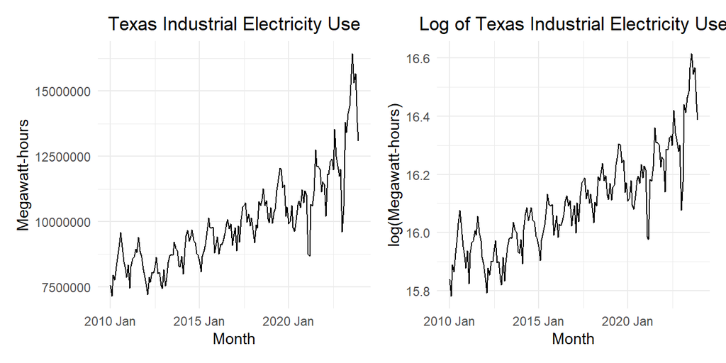

Figure 6: Monthly industrial electricity use in Texas (left) and the natural logarithm of the series (right)

```r
elec_ts <- rio::import("https://byuistats.github.io/timeseries/data/electricity_tx.csv") |>
  dplyr::select(-comments) |>
  mutate(
    date          = yearmonth(my(month)),
    t             = row_number(),
    years_elapsed = t / 12,
    month         = factor(month.abb[month(date)], levels = month.abb)
  ) |>
  as_tsibble(index = date)

elec_plot_raw <- elec_ts |>
  autoplot(.vars = megawatthours) +
  labs(
    x = "Month",
    y = "Megawatt-hours",
    title = "Texas Industrial Electricity Use"
  ) +
  theme_minimal() +
  theme(plot.title = element_text(hjust = 0.5))

elec_plot_log <- elec_ts |>
  autoplot(.vars = log(megawatthours)) +
  labs(
    x = "Month",
    y = "log(Megawatt-hours)",
    title = "Log of Texas Industrial Electricity Use"
  ) +
  theme_minimal() +
  theme(plot.title = element_text(hjust = 0.5))

elec_plot_raw | elec_plot_log
```

**TipCheck Your Understanding**

Work through the same steps we used for the airline passenger data.

- Describe the trend and seasonal variation in the time plot.
- Fit linear, quadratic, and cubic trend models with monthly indicator variables to $\log(x_t)$.
- Compare the candidates using AIC, AICc, and BIC. Which model would you choose? Justify your choice using the criteria *and* at least one other consideration.
- Check the correlogram and partial correlogram of the residuals from your chosen model. What $AR(p)$ model is appropriate for the errors?
- Fit your chosen model with $AR(p)$ errors using `ARIMA()`. How do the standard errors of the trend terms change?
- Forecast the next 5 years and plot the forecasts with the time series. Are the forecasts from fable already bias-corrected?

## Homework Preview (5 min)

- Review upcoming homework assignment
- Clarify questions

**NoteDownload Homework**

homework_5_2.qmd

Small-Group Activity

#### Small-Group Activity: Industrial Electricity Consumption in Texas

**Trend and seasonality.** Electricity use rises over time, and the growth appears to speed up in the later years. There is a clear seasonal pattern, with a peak in late summer. The log transformation keeps the seasonal swings at a similar size throughout the series.

**Candidate models.**

```r
elec_models <- elec_ts |>
  model(
    linear    = TSLM(log(megawatthours) ~ years_elapsed + month),
    quadratic = TSLM(log(megawatthours) ~ years_elapsed + I(years_elapsed^2) + month),
    cubic     = TSLM(log(megawatthours) ~ years_elapsed + I(years_elapsed^2) + I(years_elapsed^3) + month)
  )

elec_models |>
  tidy() |>
  filter(term %in% c("years_elapsed", "I(years_elapsed^2)", "I(years_elapsed^3)")) |>
  select(.model, term, estimate, std.error, p.value)
```

```
# A tibble: 6 × 5
  .model    term                estimate std.error  p.value
  <chr>     <chr>                  <dbl>     <dbl>    <dbl>
1 linear    years_elapsed       0.0353   0.00126   2.36e-62
2 quadratic years_elapsed       0.00848  0.00457   6.56e- 2
3 quadratic I(years_elapsed^2)  0.00190  0.000314  1.04e- 8
4 cubic     years_elapsed       0.0274   0.0115    1.85e- 2
5 cubic     I(years_elapsed^2) -0.00144  0.00189   4.48e- 1
6 cubic     I(years_elapsed^3)  0.000158 0.0000885 7.55e- 2
```

**Model comparison.**

```r
elec_ic <- elec_models |>
  glance() |>
  select(.model, r_squared, adj_r_squared, AIC, AICc, BIC)

elec_ic
```

Table 6: Fit statistics for the candidate models fitted to the logarithm of Texas industrial electricity use

| Model | R-squared | Adj. R-squared | AIC | AICc | BIC |
| --- | --- | --- | --- | --- | --- |
| linear | 0.8555 | 0.8443 | -898.8 | -896 | -855 |
| quadratic | 0.8832 | 0.8734 | -932.6 | -929.5 | **-885.8** |
| cubic | 0.8856 | 0.8752 | **-934.1** | **-930.5** | -884.1 |

The linear model is clearly worse than the other two. The cubic and quadratic models are close: the AICc slightly prefers the cubic model, while the BIC prefers the quadratic model. This is the kind of near-tie where the criteria do not make the decision for us. The cubic term is not significant even under OLS, which already understates the standard errors, and a cubic trend can behave erratically when extrapolated. We choose the **quadratic** model. A group that chose the cubic model for its slightly lower AICc and explained the trade-off would also be reasoning well.

**Residuals.**

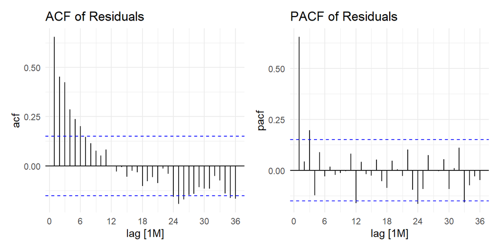

```r
elec_quad_resid <- elec_models |>
  select(quadratic) |>
  residuals()

(elec_quad_resid |> ACF(.resid, lag_max = 36) |> autoplot() + labs(title = "ACF of Residuals") + theme_minimal()) |
  (elec_quad_resid |> PACF(.resid, lag_max = 36) |> autoplot() + labs(title = "PACF of Residuals") + theme_minimal())
```

The partial correlogram has one large spike at lag 1, so we use $AR(1)$ errors.

**Regression with AR(1) errors.**

```r
elec_ar <- elec_ts |>
  model(
    quad_ar1 = ARIMA(log(megawatthours) ~ years_elapsed + I(years_elapsed^2) + month + pdq(1, 0, 0) + PDQ(0, 0, 0))
  )

bind_rows(
  elec_models |> select(quadratic) |> tidy(),
  elec_ar |> tidy()
) |>
  filter(term %in% c("years_elapsed", "I(years_elapsed^2)", "ar1")) |>
  select(.model, term, estimate, std.error)
```

```
# A tibble: 5 × 4
  .model    term               estimate std.error
  <chr>     <chr>                 <dbl>     <dbl>
1 quadratic years_elapsed       0.00848  0.00457
2 quadratic I(years_elapsed^2)  0.00190  0.000314
3 quad_ar1  ar1                 0.653    0.0579
4 quad_ar1  years_elapsed       0.00911  0.00903
5 quad_ar1  I(years_elapsed^2)  0.00187  0.000624
```

As with the airline data, the trend estimates are similar but the standard errors are larger once the $AR(1)$ errors are included.

**Forecast.**

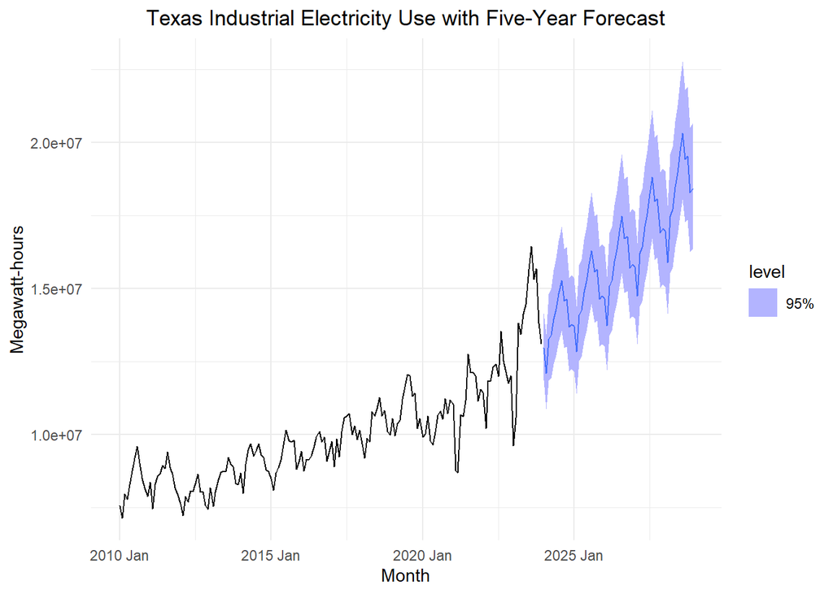

```r
elec_future <- new_data(elec_ts, n = 5 * 12) |>
  mutate(
    t             = nrow(elec_ts) + row_number(),
    years_elapsed = t / 12,
    month         = factor(month.abb[month(date)], levels = month.abb)
  )

elec_ar |>
  forecast(new_data = elec_future) |>
  autoplot(elec_ts, level = 95) +
  labs(
    x = "Month",
    y = "Megawatt-hours",
    title = "Texas Industrial Electricity Use with Five-Year Forecast"
  ) +
  theme_minimal() +
  theme(plot.title = element_text(hjust = 0.5))
```

Because the model formula includes `log()`, the `.mean` forecasts from fable are already bias-corrected. No additional correction factor should be applied.